# NYPD Shooting Incident Report

Amrit Sanal

2022-02-01

### Introduction

This Data is a List of every shooting incident that occurred in NYC going back to 2006 through the end of the previous calendar year.This is a robust and extensive dataset that we will analyze to see if there are any patterns or noticeable trends within this data that will give us insights on shootings performed by the NYPD.

##Let’s import the Dataset

Lets begin by bringing in the dataset via a URL that links directly to the download of the CSV. We will start by importing the tidyverse library then bringing in the data.

```r
library(tidyverse)
url_in <- "https://data.cityofnewyork.us/api/views/833y-fsy8/rows.csv?accessType=DOWNLOAD"

urls <- str_c(url_in)

nypd_data <- read_csv(urls[1])
```

##Tidying up the data

After that, let’s make sure that we are only going to be using the columns that we need for this analysis. This includes getting rid of inconsequential columns such as latitude and longitude, which have too granular of a bearing on shootings. The borough is a much better column to see if there’s any geographical bearing to shooting incidence.

```r
sapply(nypd_data, function(x) sum(is.na(x)))
```

```
##            INCIDENT_KEY              OCCUR_DATE              OCCUR_TIME
##                       0                       0                       0
##                    BORO                PRECINCT       JURISDICTION_CODE
##                       0                       0                       2
##           LOCATION_DESC STATISTICAL_MURDER_FLAG          PERP_AGE_GROUP
##                   13581                       0                    8295
##                PERP_SEX               PERP_RACE           VIC_AGE_GROUP
##                    8261                    8261                       0
##                 VIC_SEX                VIC_RACE              X_COORD_CD
##                       0                       0                       0
##              Y_COORD_CD                Latitude               Longitude
##                       0                       0                       0
##                 Lon_Lat
##                       0
```

```r
nypd_data <- nypd_data %>% pivot_longer(cols = -c(INCIDENT_KEY, `BORO`, OCCUR_TIME, PRECINCT, JURISDICTION_CODE,LOCATION_DESC,STATISTICAL_MURDER_FLAG, PERP_AGE_GROUP, PERP_SEX,PERP_RACE, VIC_AGE_GROUP,VIC_SEX, VIC_RACE, X_COORD_CD, Y_COORD_CD, Latitude, Longitude, Lon_Lat),
names_to = "OCCUR_DATE",
values_to = "Date") %>%
select(-c(INCIDENT_KEY, OCCUR_TIME, JURISDICTION_CODE,LOCATION_DESC,PERP_AGE_GROUP, PERP_SEX, PERP_RACE, X_COORD_CD, Y_COORD_CD, Latitude, Longitude, Lon_Lat))

nypd_data
```

```
## # A tibble: 23,585 x 8
##    BORO     PRECINCT STATISTICAL_MURD~ VIC_AGE_GROUP VIC_SEX VIC_RACE OCCUR_DATE
##    <chr>       <dbl> <lgl>             <chr>         <chr>   <chr>    <chr>
##  1 BRONX          52 TRUE              25-44         F       BLACK H~ OCCUR_DATE
##  2 QUEENS        106 FALSE             65+           M       WHITE    OCCUR_DATE
##  3 BROOKLYN       77 FALSE             18-24         F       BLACK    OCCUR_DATE
##  4 BRONX          40 FALSE             <18           M       BLACK    OCCUR_DATE
##  5 QUEENS        100 FALSE             18-24         M       BLACK    OCCUR_DATE
##  6 BROOKLYN       67 FALSE             <18           M       BLACK    OCCUR_DATE
##  7 BROOKLYN       77 FALSE             <18           M       BLACK    OCCUR_DATE
##  8 BROOKLYN       81 FALSE             25-44         M       BLACK    OCCUR_DATE
##  9 QUEENS        101 FALSE             18-24         M       BLACK    OCCUR_DATE
## 10 QUEENS        106 FALSE             18-24         M       BLACK    OCCUR_DATE
## # ... with 23,575 more rows, and 1 more variable: Date <chr>
```

It is also worth looking at a summary of this data to see if there are any noticeable statistical anomalies.

```r
summary(nypd_data)
```

```
##      BORO              PRECINCT      STATISTICAL_MURDER_FLAG VIC_AGE_GROUP
##  Length:23585       Min.   :  1.00   Mode :logical           Length:23585
##  Class :character   1st Qu.: 44.00   FALSE:19085             Class :character
##  Mode  :character   Median : 69.00   TRUE :4500              Mode  :character
##                     Mean   : 66.21
##                     3rd Qu.: 81.00
##                     Max.   :123.00
##    VIC_SEX            VIC_RACE          OCCUR_DATE            Date
##  Length:23585       Length:23585       Length:23585       Length:23585
##  Class :character   Class :character   Class :character   Class :character
##  Mode  :character   Mode  :character   Mode  :character   Mode  :character
##
##
##
```

From the initial look, there don’t seem to be any statistical anomalies that are worth a second look.

##Analysis and Model

Now that our data is tidied up, I want to look more closely at how the racial impact of these shootings, and I want to compare it to the boroughs to see if there is any correlation between these variables.

First, I want to separate these values into a separate dataframe.

```r
race_borough_freq <- table(nypd_data$VIC_RACE, nypd_data$BORO)
race_borough_freq_dataframe <- as.data.frame(race_borough_freq)

race_borough_freq_dataframe
```

```
##                              Var1          Var2 Freq
## 1  AMERICAN INDIAN/ALASKAN NATIVE         BRONX    4
## 2        ASIAN / PACIFIC ISLANDER         BRONX   52
## 3                           BLACK         BRONX 3832
## 4                  BLACK HISPANIC         BRONX 1073
## 5                         UNKNOWN         BRONX   23
## 6                           WHITE         BRONX  115
## 7                  WHITE HISPANIC         BRONX 1602
## 8  AMERICAN INDIAN/ALASKAN NATIVE      BROOKLYN    3
## 9        ASIAN / PACIFIC ISLANDER      BROOKLYN  111
## 10                          BLACK      BROOKLYN 8119
## 11                 BLACK HISPANIC      BROOKLYN  501
## 12                        UNKNOWN      BROOKLYN   23
## 13                          WHITE      BROOKLYN  228
## 14                 WHITE HISPANIC      BROOKLYN  749
```

[output cut: 21 more lines]

Immediately from seeing this, we can see that there is a massive discrepancy between all of the races and shooting frequency. I will now split the dataframes into each borough and then create a visualization for each borough and the frequency at which shootings occur in each borough. As an example, I will show what the data for one borough looks like

```r
race_borough_freq_dataframe <- split(race_borough_freq_dataframe, f = race_borough_freq_dataframe$Var2)

bronx_data <- race_borough_freq_dataframe$BRONX
bronx_data$Percent <- round((bronx_data$Freq / sum(bronx_data$Freq)*100),2)

brooklyn_data <- race_borough_freq_dataframe$BROOKLYN
brooklyn_data$Percent <- round((brooklyn_data$Freq / sum(brooklyn_data$Freq)*100),2)


staten_data <- race_borough_freq_dataframe$`STATEN ISLAND`
staten_data$Percent <- round((staten_data$Freq / sum(staten_data$Freq)*100),2)


manhattan_data <- race_borough_freq_dataframe$MANHATTAN
manhattan_data$Percent <- round((manhattan_data$Freq / sum(manhattan_data$Freq)*100),2)

queens_data <- race_borough_freq_dataframe$QUEENS
queens_data$Percent <- round((queens_data$Freq / sum(queens_data$Freq)*100),2)

queens_data
```

```
##                              Var1   Var2 Freq Percent
## 22 AMERICAN INDIAN/ALASKAN NATIVE QUEENS    2    0.06
## 23       ASIAN / PACIFIC ISLANDER QUEENS  125    3.54
## 24                          BLACK QUEENS 2568   72.71
## 25                 BLACK HISPANIC QUEENS  225    6.37
## 26                        UNKNOWN QUEENS   13    0.37
## 27                          WHITE QUEENS  145    4.11
## 28                 WHITE HISPANIC QUEENS  454   12.85
```

Now lets look at some visualizations of this data for each borough to see if there are any correlations or discrepancies.

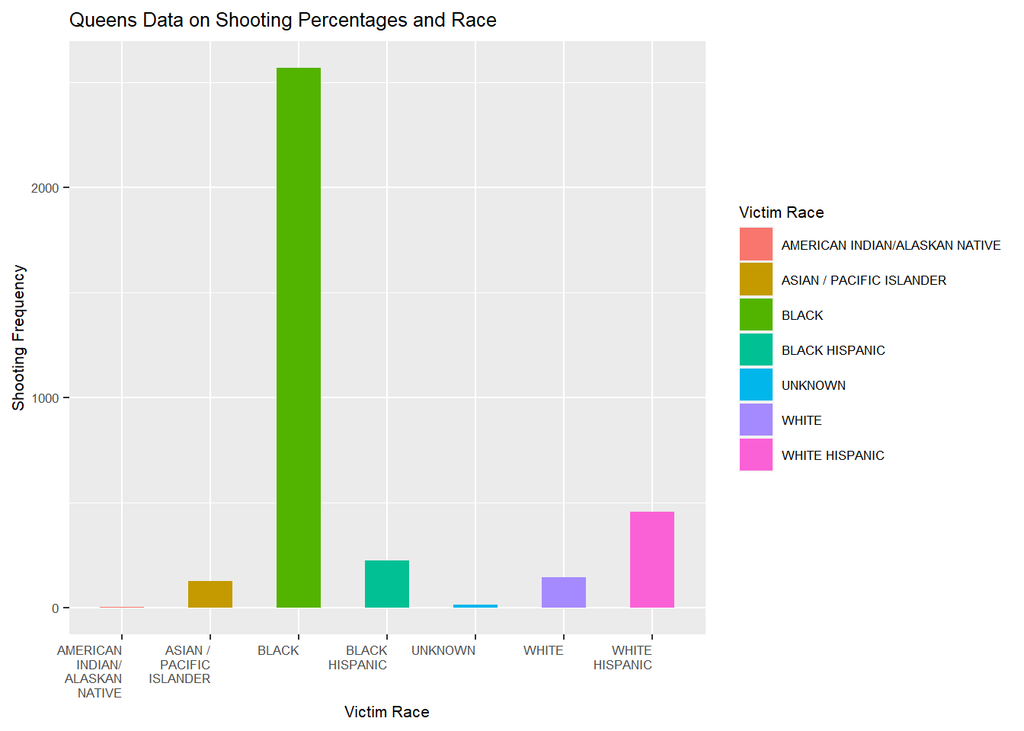

```r
ggplot(queens_data, aes(x=Var1, y=Freq, fill=Var1)) + geom_bar(stat="identity",width = 0.5, position = position_dodge(width=2)) + scale_x_discrete(labels = function(x) str_wrap(x, width = 0))+
theme(text = element_text(size=8),
axis.text.x = element_text(angle=0, hjust=1)) +
labs (title = "Queens Data on Shooting Percentages and Race",x="Victim Race", y= "Shooting Frequency", fill = "Victim Race")
```

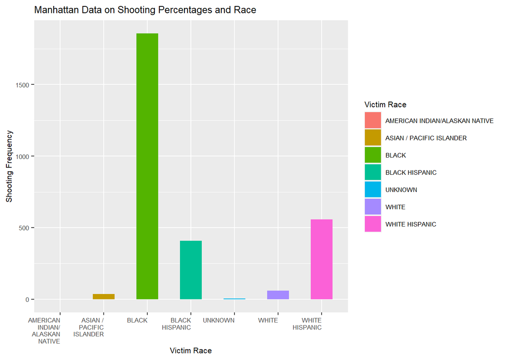

```r
ggplot(manhattan_data, aes(x=Var1, y=Freq, fill=Var1)) + geom_bar(stat="identity",width = 0.5, position = position_dodge(width=2)) + scale_x_discrete(labels = function(x) str_wrap(x, width = 0))+
theme(text = element_text(size=8),
axis.text.x = element_text(angle=0, hjust=1)) +
labs (title = "Manhattan Data on Shooting Percentages and Race",x="Victim Race", y= "Shooting Frequency", fill = "Victim Race")
```

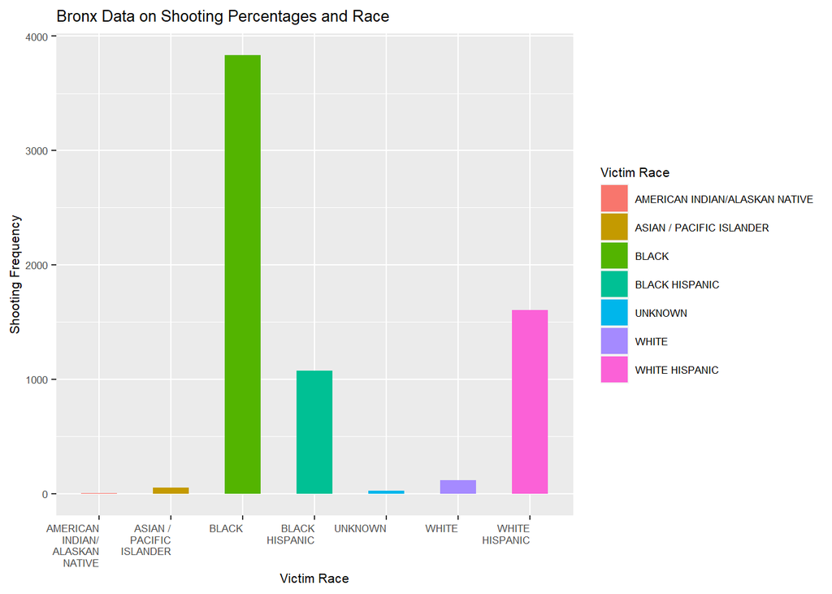

```r
ggplot(bronx_data, aes(x=Var1, y=Freq, fill=Var1)) + geom_bar(stat="identity",width = 0.5, position = position_dodge(width=2)) + scale_x_discrete(labels = function(x) str_wrap(x, width = 0))+
theme(text = element_text(size=8),
axis.text.x = element_text(angle=0, hjust=1)) +
labs (title = "Bronx Data on Shooting Percentages and Race",x="Victim Race", y= "Shooting Frequency", fill = "Victim Race")
```

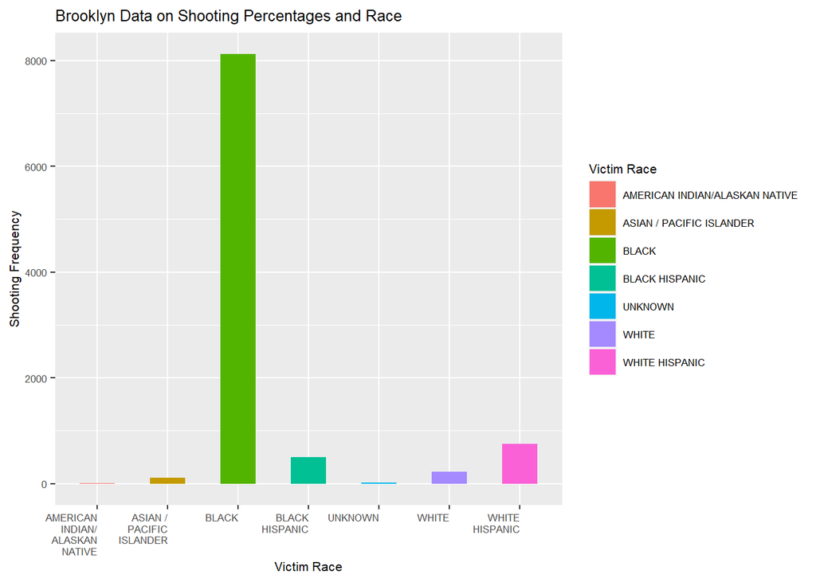

```r
ggplot(brooklyn_data, aes(x=Var1, y=Freq, fill=Var1)) + geom_bar(stat="identity",width = 0.5, position = position_dodge(width=2)) + scale_x_discrete(labels = function(x) str_wrap(x, width = 0))+
theme(text = element_text(size=8),
axis.text.x = element_text(angle=0, hjust=1)) +
labs (title = "Brooklyn Data on Shooting Percentages and Race",x="Victim Race", y= "Shooting Frequency", fill = "Victim Race")
```

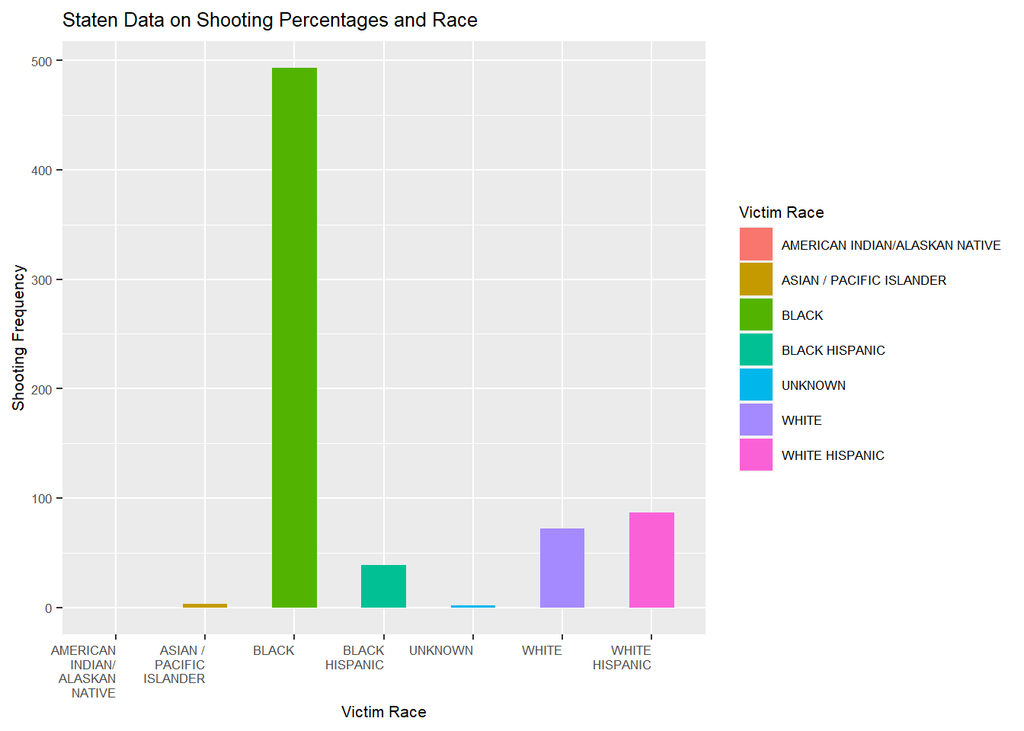

```r
ggplot(staten_data, aes(x=Var1, y=Freq, fill=Var1)) + geom_bar(stat="identity",width = 0.5, position = position_dodge(width=2)) + scale_x_discrete(labels = function(x) str_wrap(x, width = 0))+
theme(text = element_text(size=8),
axis.text.x = element_text(angle=0, hjust=1)) +
labs (title = "Staten Data on Shooting Percentages and Race",x="Victim Race", y= "Shooting Frequency", fill = "Victim Race")
```

This data is showing a pretty clear high incidence rate between the shooting frequency of Black New Yorkers over every other race in every borough. This calls for further analysis. We need to add another variable to this equation. I will look at how high the shooting percentages have been for Black New Yorkers over the historical time frame this dataset allows for against the whole of New York.

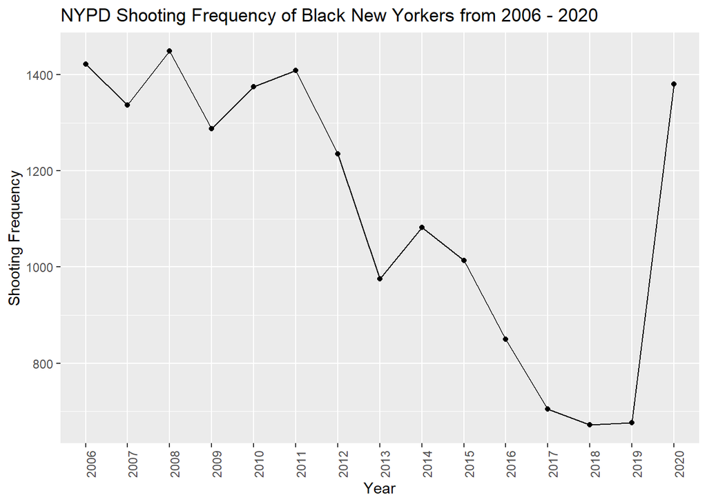

```r
B <- subset(nypd_data, VIC_RACE=='BLACK', select=c(VIC_RACE, Date))
n <- 4
B$YEAR <- substr(B$Date, nchar(B$Date) - n + 1, nchar(B$Date))
B <- subset(B, select = -c(Date))
RACE <- table(B$YEAR)
RACE <- as.data.frame(RACE)

ggplot(data=RACE, aes(x=Var1, y=Freq, group=1)) +
    geom_line()+
    geom_point()+
    theme(axis.text.x = element_text(angle = 90, hjust = 1))+
labs (title = "NYPD Shooting Frequency of Black New Yorkers from 2006 - 2020",x="Year", y= "Shooting Frequency")
```

Now that we can see frequency at which Black New Yorkers get shot by the NYPD historically, we can see an odd trend to the data, primarily that between 2017 and 2019, there were comparatively very few shootings of Black New Yorkers in contrast to the years before and seemingly the year after as well.

In addition to this analysis, we should also conduct a model of this data to see if we can predict the amount of Black Americans that will die as a part of a shooting.

```r
black_data <- nypd_data[nypd_data$VIC_RACE == "BLACK", ]

X <- subset(black_data, STATISTICAL_MURDER_FLAG == 'TRUE', select=c(STATISTICAL_MURDER_FLAG, Date))

n <- 4
X$YEAR <- substr(X$Date, nchar(X$Date) - n + 1, nchar(X$Date))
X <- subset(X, select = -c(Date))

XRace <- table(X$YEAR)
XRace <- as.data.frame(XRace)

finalRace = merge(x = RACE, y = XRace, by = "Var1")


mod <- lm(Freq.x ~ Freq.y, data=finalRace)

summary(mod)
```

```
##
## Call:
## lm(formula = Freq.x ~ Freq.y, data = finalRace)
##
## Residuals:
##     Min      1Q  Median      3Q     Max
## -156.78  -58.80   13.88   69.21  137.93
##
## Coefficients:
##             Estimate Std. Error t value Pr(>|t|)
## (Intercept)  210.263     88.710    2.37   0.0339 *
## Freq.y         4.347      0.405   10.73 7.86e-08 ***
## ---
## Signif. codes:  0 '***' 0.001 '**' 0.01 '*' 0.05 '.' 0.1 ' ' 1
##
## Residual standard error: 95.95 on 13 degrees of freedom
## Multiple R-squared:  0.8986, Adjusted R-squared:  0.8908
## F-statistic: 115.2 on 1 and 13 DF,  p-value: 7.861e-08
```

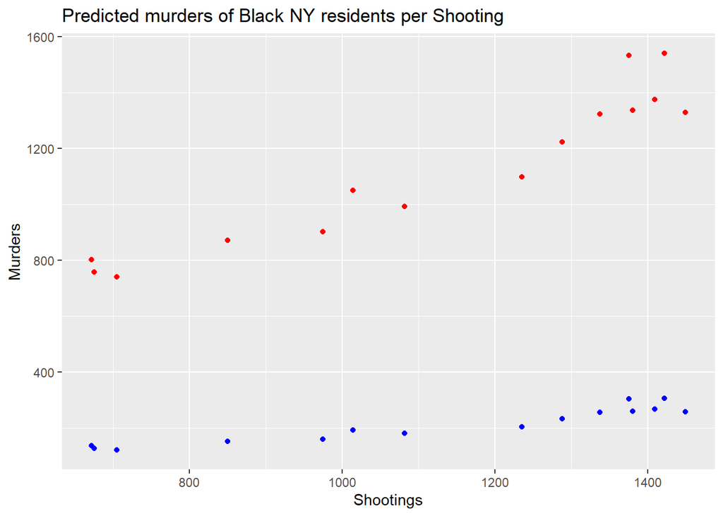

```r
finalRace_w_pred <- finalRace %>% mutate (pred = predict(mod))

finalRace_w_pred %>% ggplot () +
      geom_point(aes (x = Freq.x, y =Freq.y), color = "blue") +
      geom_point (aes (x= Freq.x, y = pred), color = "red")+
      labs (title = "Predicted murders of Black NY residents per Shooting",x="Shootings", y= "Murders")
```

##Potential Bias

As we have learned in class, bias exists in everyone, and in data scientists, it is extremely important to denote our own biases and take that into account within our analyses. My personal biases regarding this analysis are that I am a very liberal leaning person of color. While I believe I did a fair analysis, I could have been subconsciously representing the data to prove an injustice, rather than prove a trend that exists in the data.

I think that with the dataset itself, there is very little bias. The provenance of this data comes from the city of New York and the only potential source of bias is that this data could not be the full dataset, that police have a motive to potentially hide shooting data, especially considering all the controversy behind police practices in recent times.

##Conclusion